# ZEAL DTA GWAS + JLM on the SNP50K panel — 1000-permutation FWER

GWAS + JLM on the SNP50K panel. Significance is a genome-wide FWER from a 1000-permutation null (per scan): the Manhattan line is the -log10P exceeded by only 5% of permutations, and candidate/peak calls report whether they clear it.

Author

Fausto Rodríguez-Zapata

Published

July 16, 2026

**ImportantGenotype at 0.4× skim: why ancestry, not per-SNP**

SNP50K is 51,991 teosinte-vs-B73 sites pileup-genotyped at ~0.4× — hard genotypes are unusable (70% missing, ~0% hom-ALT), so ancestry is inferred from the per-sample allele **counts**. The **per-SNP genotype (bcftools HWE-posterior) (Panel B)** is therefore λ_GC-deflated (sparse mean-imputation); the **RTIGER ancestry mosaic (Panel C)** is the usable, block-smoothed genotype (teosinte presence 0.111, matching the established BzeaSeq ~0.101). This is the ZEAL-specific reason ancestry inference is mandatory — and the direct analog of the per-SNP-vs-block contrast in the TeoNAM notebook.

The central result mirrors TeoNAM: **K = teosinte-ancestry relatedness is collinear with the flowering QTL**, so the mixed model absorbs the very signal it protects — the flowering candidates (`ZmCCT10`, `ZCN8`) are suppressed under MLM. As in Chen 2019, the DTA QTL are therefore the province of **JLM** (nested-in-family stepwise), not the MLM Manhattan.

```r
library(here)
library(data.table)
library(ggplot2)
library(fastman)
library(ggrepel)
library(ggtext)
library(scales)
library(cowplot)
source(here("scripts/teonam_notebook_plots.R")) # shared: plot_manhattan/lollipop, lambda_gc, LOD
```

```r
mlm <- fread(here("data/zeal/dta_gwas_mlm_rtiger_mosaic_donor_accession_snp50k.csv")) # Panel C
gt <- fread(here("data/zeal/dta_gwas_mlm_hwe_post_gt_donor_accession_snp50k.csv")) # Panel B
ols <- fread(here("data/zeal/dta_gwas_ols_donor_accession_snp50k.csv"))[is.finite(P) & P > 0]
overlap <- here("results/sim/zeal/dta_candidate_overlap.csv")
lam <- function(p) {
  p <- p[is.finite(p) & p > 0 & p <= 1]
  round(median(qchisq(p, 1, lower.tail = FALSE)) / qchisq(0.5, 1), 2)
}
# Significance = genome-wide FWER from a 1000-permutation null (scripts/zeal_gwas_perm.R),
# stored per (trait, model, geno) in data/zeal/gwas_perm_thresholds.csv. thr() reads the
# -log10P line for a panel; a marker is significant iff its -log10P exceeds that line.
TR <- "DTA"
thr <- function(model, geno, a = 0.05) gwas_thr(TR, model, geno, a)
thr_ols <- thr("ols", "rtiger_mosaic") # OLS runs on the RTIGER mosaic
thr_mlm <- thr("mlm", "rtiger_mosaic") # Panel C
thr_gt <- thr("mlm", "hwe_post_gt") # Panel B (per-SNP)
nsig <- function(p, t) sum(-log10(p) > t, na.rm = TRUE) # markers above the FWER line
```

**NoteSignificance = 1000-permutation genome-wide FWER (5%)**

Every Manhattan’s dotted line is the **−log₁₀P exceeded by only 5% of 1000 permutations** of that scan (a genome-wide max-−log₁₀P null; `scripts/zeal_gwas_perm.R`), stored per (trait, model, geno) in `data/zeal/gwas_perm_thresholds.csv`. A marker is significant iff its −log₁₀P clears that line. The line’s height differs per panel with the null. Candidate/peak tables report whether the marker clears the 5% FWER line.

## Candidate gene registry

Curated evidence for each **candidate** (tier, causal direction, evidence type, phenotype, and a DOI link) from the tracked registry (`reference/candidate_genes.csv` × `candidate_evidence.csv`). These are the genes starred on the Manhattans and labelled on the lollipop; loci without B73 v5 coordinates still appear here but are not plotted.

```r
candidate_table(TR)
```

Candidate genes for DTA from the tracked registry (reference/candidate_*.csv): 11 loci (11 mapped to B73 v5, 0 unmapped). DOI links where curated; “TODO” = evidence not yet curated.

| gene | full name | locus | tier | direction | evidence | phenotype / note | reference |
| --- | --- | --- | --- | --- | --- | --- | --- |
| *zagl1* |  | 1:283.8 Mb |  |  |  |  | TODO |
| *zmads69* |  | 3:161.2 Mb |  |  |  |  | TODO |
| *zcn12* |  | 3:202.8 Mb |  |  |  |  | TODO |
| *tu1* | tu1 (tunicate1 / ZMM19 / MADS19) | 4:183.9 Mb |  |  |  |  | TODO |
| *zmm31* |  | 5:7.4 Mb |  |  |  |  | TODO |
| *si1* |  | 6:94.5 Mb |  |  |  |  | TODO |
| *zag1* |  | 6:142.7 Mb |  |  |  |  | TODO |
| *dlf1* |  | 7:184.5 Mb |  |  |  |  | TODO |
| *zcn8* |  | 8:126.7 Mb |  |  |  |  | TODO |
| *zmcct9* |  | 9:121.0 Mb |  |  |  |  | TODO |
| *zmcct10* |  | 10:96.2 Mb |  |  |  |  | TODO |

## Candidate genes: closest marker vs window-max marker

For each maize flowering candidate (B73 v5), the closest marker to the gene body vs the highest −log₁₀P marker within ±500 kb in the RTIGER-mosaic **MLM (Family+K)** scan (Panel C). The same v5 flowering candidates as TeoNAM (these are maize genes; teosinte introgression at them drives DTA in both populations).

```r
sc <- copy(mlm)[is.finite(P) & P > 0][, logP := -log10(P)]
gg <- fread(here("data/teonam/dta_candidate_genes.tsv"))
gg[, chr := as.integer(chr)][, qtl := ifelse(qtl_chen2019 == "" | is.na(qtl_chen2019), paste0("DTA(chr", chr, ")"), qtl_chen2019)]
WIN <- 5e5
ctab <- rbindlist(lapply(seq_len(nrow(gg)), function(i) {
  ch <- gg$chr[i]
  s <- gg$start[i]
  e <- gg$end[i]
  m <- sc[CHR == ch]
  if (!nrow(m)) {
    return(NULL)
  }
  d <- pmax(0L, pmax(s - m$BP, m$BP - e))
  kc <- which.min(d)
  w <- m[BP >= s - WIN & BP <= e + WIN]
  kw <- if (nrow(w)) which.max(w$logP) else NA
  data.table(
    gene = gg$symbol[i], QTL = gg$qtl[i], chr = ch, `gene start (v5)` = s,
    `closest Δstart (bp)` = m$BP[kc] - s, `closest -log10P` = round(m$logP[kc], 2),
    `window-max -log10P` = if (nrow(w)) round(w$logP[kw], 2) else NA_real_,
    `clears perm 5%` = if (nrow(w)) (w$logP[kw] >= thr_mlm) else NA
  )
}))
setorder(ctab, chr, `gene start (v5)`)
knitr::kable(ctab,
  format.args = list(big.mark = ","),
  caption = sprintf("DTA candidates (B73 v5): closest vs window-max (±500 kb) marker, RTIGER-mosaic MLM (Family+K) scan; 'clears perm 5%%' = window-max exceeds the 1000-permutation FWER line (-log10P = %.2f).", thr_mlm)
)
```

DTA candidates (B73 v5): closest vs window-max (±500 kb) marker, RTIGER-mosaic MLM (Family+K) scan; ‘clears perm 5%’ = window-max exceeds the 1000-permutation FWER line (-log10P = 4.56).

| gene | QTL | chr | gene start (v5) | closest Δstart (bp) | closest -log10P | window-max -log10P | clears perm 5% |
| --- | --- | --- | --- | --- | --- | --- | --- |
| zagl1 | DTA(chr1) | 1 | 283,849,414 | 12,915 | 0.70 | 0.86 | FALSE |
| zmads69 | DTA(chr3) | 3 | 161,172,047 | 29,298 | 0.45 | 0.85 | FALSE |
| zcn12 | DTA3.2 | 3 | 202,794,887 | 3,509 | 1.10 | 1.33 | FALSE |
| tu1 | DTA4.1 | 4 | 183,877,156 | -2,361 | 1.43 | 1.46 | FALSE |
| zmm31 | DTA5.1 | 5 | 7,374,462 | -50,600 | 0.37 | 0.72 | FALSE |
| si1 | DTA6.1 | 6 | 94,458,037 | 12,722 | 0.80 | 0.80 | FALSE |
| zag1 | DTA6.2 | 6 | 142,692,209 | 65,043 | 0.32 | 0.40 | FALSE |
| dlf1 | DTA7.2 | 7 | 184,528,042 | -547,303 | 1.23 | NA | NA |
| zcn8 | DTA(chr8) | 8 | 126,678,681 | -57,791 | 0.65 | 0.99 | FALSE |
| zmcct9 | DTA(chr9) | 9 | 120,960,326 | 7,897 | 0.00 | 0.01 | FALSE |
| zmcct10 | DTA(chr10) | 10 | 96,175,873 | -2,308 | 2.68 | 5.01 | TRUE |

## OLS → MLM: the flowering confound and structure control

Here **Family** is the **82 donor-accession** fixed factor (parent-plant-level structure correction) that the MLM and per-marker OLS scans were actually computed with — a stronger correction than the 5 donor **taxa** the JLM nests on. It likely over-corrects population structure and costs some power; a taxon-level (5) MLM/OLS rerun is a pending comparison (see `TERMINOLOGY.md`).

The fixed-effect OLS (Family + marker, no K) vs the MLM (Family + K) on the RTIGER mosaic, same fixed part. OLS is intrinsically inflated (ancestry-block LD, unfixable by any fixed factor); K deflates λ toward 1 **and** collapses the flowering peaks (`ZmCCT10`), the ancestry-QTL confound.

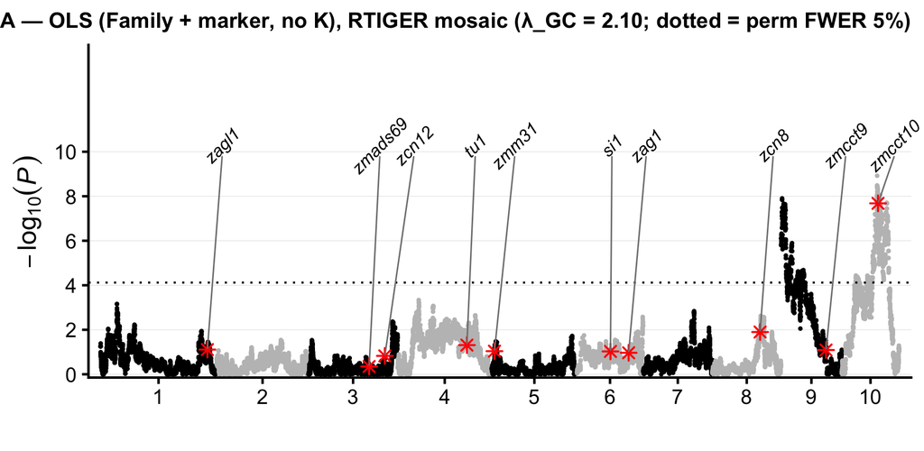

```r
plot_manhattan(ols,
  sprintf("ZEAL DTA — OLS (Family + marker, no K), RTIGER mosaic (λ_GC = %.2f; dotted = perm FWER 5%%)", lam(ols$P)),
  overlap_csv = overlap, lod = thr_ols,
  out_png = here("results/sim/zeal/dta_gwas_ols_manhattan_fdr_snp50k.png")
)
```

```r
lam_tab <- data.table(
  model = c("OLS (Family + marker, no K)", "MLM (Family + K)"),
  markers = c(nrow(ols), nrow(mlm)),
  lambda_GC = c(lam(ols$P), lam(mlm$P)),
  `n > perm 5%` = c(nsig(ols$P, thr_ols), nsig(mlm$P, thr_mlm)),
  max_logP = round(c(max(-log10(ols$P)), max(-log10(mlm$P))), 2)
)
knitr::kable(lam_tab, caption = "OLS vs MLM on the RTIGER mosaic (same Family fixed part): K deflates genomic inflation; n markers above each scan's 1000-permutation 5% FWER line.")
```

OLS vs MLM on the RTIGER mosaic (same Family fixed part): K deflates genomic inflation; n markers above each scan’s 1000-permutation 5% FWER line.

[output not shown]

```r
ov <- fread(overlap)
peak_at <- function(scan, ch, s) {
  w <- scan[CHR == ch & abs(BP - s) <= 5e5 & is.finite(P) & P > 0]
  if (!nrow(w)) NA_real_ else round(max(-log10(w$P)), 2)
}
cmp <- ov[, .(
  gene = symbol, chr,
  `OLS peak` = mapply(peak_at, list(ols), chr, start),
  `MLM peak` = mapply(peak_at, list(mlm), chr, start)
)]
cmp[, `drop (OLS−MLM)` := round(`OLS peak` - `MLM peak`, 2)]
setorder(cmp, -`OLS peak`)
knitr::kable(cmp, caption = "Local peak -log10P (±500 kb) per candidate: OLS vs MLM. K suppresses the ancestry-collinear flowering peaks.")
```

Local peak -log10P (±500 kb) per candidate: OLS vs MLM. K suppresses the ancestry-collinear flowering peaks.

| gene | chr | OLS peak | MLM peak | drop (OLS−MLM) |
| --- | --- | --- | --- | --- |
| dlf1 | 7 | NA | NA | NA |
| zmcct10 | 10 | 7.68 | 5.01 | 2.67 |
| zcn8 | 8 | 1.90 | 0.99 | 0.91 |
| tu1 | 4 | 1.31 | 1.46 | -0.15 |
| zagl1 | 1 | 1.11 | 0.86 | 0.25 |
| zmcct9 | 9 | 1.09 | 0.01 | 1.08 |
| zmm31 | 5 | 1.04 | 0.72 | 0.32 |
| si1 | 6 | 1.03 | 0.80 | 0.23 |
| zag1 | 6 | 0.96 | 0.40 | 0.56 |
| zcn12 | 3 | 0.83 | 1.33 | -0.50 |
| zmads69 | 3 | 0.35 | 0.85 | -0.50 |

## JLM QTL genomic distribution (Panel A)

DTA QTL from JLM (TASSEL StepwiseOLS, nested in taxon, entry by a 1000-permutation empirical α = 0.05 (Chen-style genome-wide FWER; per-trait)). JLM QTL are selected by the stepwise enter/exit P (a model-selection gate), independent of the per-scan permutation FWER line used for the GWAS Manhattans below. Model-independent — Chen’s primary DTA analysis.

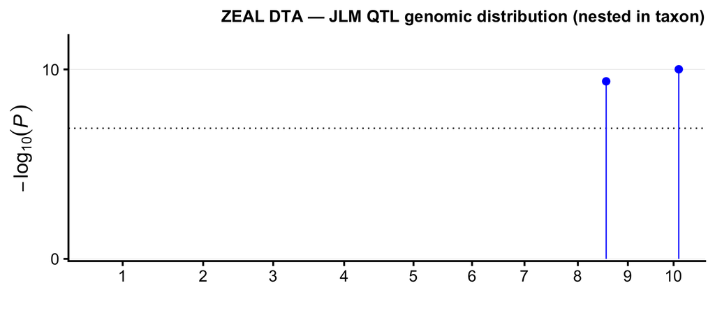

```r
p_lolli <- plot_lollipop(
  here("results/sim/zeal/tassel/dta_jlm_native1.txt"), mlm,
  "ZEAL DTA — JLM QTL genomic distribution (nested in taxon)",
  overlap_csv = overlap,
  out_png = here("results/sim/zeal/dta_jlm_lollipop_snp50k.png")
)
p_lolli
```

## MLM (Family + K), RTIGER ancestry mosaic (Panel C)

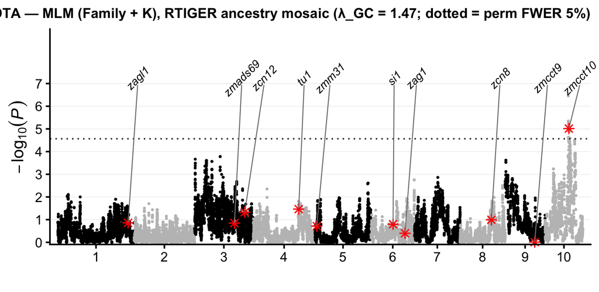

```r
p_mlm <- plot_manhattan(mlm,
  sprintf("ZEAL DTA — MLM (Family + K), RTIGER ancestry mosaic (λ_GC = %.2f; dotted = perm FWER 5%%)", lam(mlm$P)),
  overlap_csv = overlap, lod = thr_mlm, out_png = here("results/sim/zeal/dta_gwas_mlm_rtiger_mosaic_manhattan_fdr_snp50k.png")
)
p_mlm
```

```r
cat(sprintf("%d markers clear the 5%% FWER line (-log10P = %.2f)\n", nsig(mlm$P, thr_mlm), thr_mlm))
```

```
35 markers clear the 5% FWER line (-log10P = 4.56)
```

## Composite (A: JLM · B: per-SNP MLM · C: RTIGER-mosaic MLM)

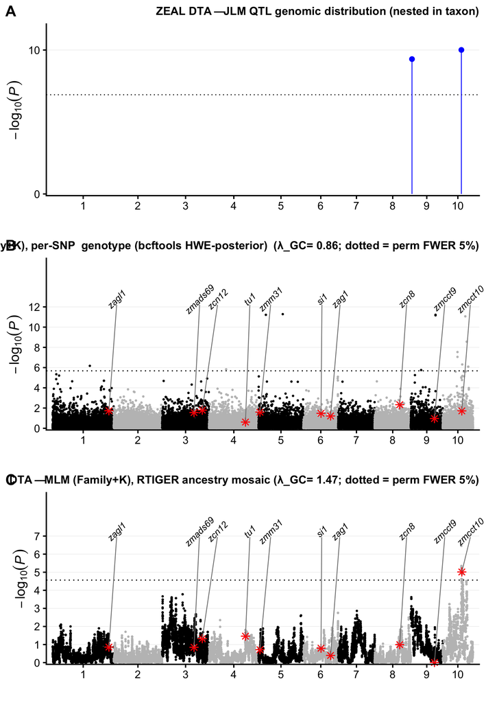

```r
p_B <- plot_manhattan(gt,
  sprintf("DTA — MLM (Family+K), per-SNP genotype (bcftools HWE-posterior) (λ_GC = %.2f; dotted = perm FWER 5%%)", lam(gt$P)),
  overlap_csv = overlap, lod = thr_gt
)
p_C <- plot_manhattan(mlm,
  sprintf("DTA — MLM (Family+K), RTIGER ancestry mosaic (λ_GC = %.2f; dotted = perm FWER 5%%)", lam(mlm$P)),
  overlap_csv = overlap, lod = thr_mlm
)
composite <- cowplot::plot_grid(p_lolli, p_B, p_C, ncol = 1, labels = c("A", "B", "C"), label_size = 20, align = "v", axis = "lr")
ggsave(here("results/sim/zeal/dta_composite_snp50k.png"), composite, width = 9, height = 13, dpi = 200, bg = "white")
composite
```

## Multi-caller DTA scan (control · nNIL · RTIGER · LB-Impute · binhmm)

The ZEAL analog of the TeoNAM DTA five-caller composite: the same DTA MLM (Family+K) scan on each ancestry caller’s recovered genotypes, at the real ~0.4× depth (not a coverage sweep). The scientific content here is **caller reliability at low coverage**: the ancestry mosaic must be **block/bin-aggregated** — the two aggregated callers (RTIGER per-donor segments; binhmm 1 Mb bins) recover the correct teosinte fraction (~0.10, matching the established BzeaSeq), while per-SNP calling (control) and the fresh per-SNP HMM recalls (nNIL, LB-Impute) **under-call** and give λ-deflated scans.

```r
callers <- c(control = "hwe_post_gt", nNIL = "nnil_mosaic", RTIGER = "rtiger_mosaic", `LB-Impute` = "lbimpute_mosaic", binhmm = "binhmm_mosaic")
tb1 <- fread(here("data/teonam/dta_candidate_genes.tsv"))[symbol == "zmcct10"]
ctab2 <- rbindlist(lapply(names(callers), function(nm) {
  g <- callers[[nm]]
  sc <- fread(here(sprintf("data/zeal/dta_gwas_mlm_%s_donor_accession_snp50k.csv", g)))
  mf <- here(sprintf("data/zeal/zeal_%s.rds", g))
  pres <- if (file.exists(mf)) {
    st <- readRDS(mf)$state
    round(mean(st %in% c(1L, 2L), na.rm = TRUE), 3)
  } else {
    NA_real_
  }
  sc <- sc[is.finite(P) & P > 0]
  z <- sc[CHR == tb1$chr & abs(BP - tb1$start) <= 5e5]
  data.table(
    caller = nm, `teosinte presence` = pres, lambda_GC = lam(sc$P),
    `n > perm 5%` = nsig(sc$P, gwas_thr(TR, "mlm", g)),
    `zmcct10 -log10P` = if (nrow(z)) round(max(z[is.finite(P) & P > 0, -log10(P)]), 2) else NA_real_
  )
}))
knitr::kable(ctab2, caption = "DTA MLM (Family+K) by ancestry caller at 0.4×, with n markers above the caller's own 1000-permutation 5% FWER line and the zmcct10 window-max -log10P. Aggregated callers (RTIGER, binhmm) recover teosinte presence ~0.10; per-SNP (control) and per-SNP recalls (nNIL, LB-Impute) under-call and deflate λ_GC.")
```

DTA MLM (Family+K) by ancestry caller at 0.4×, with n markers above the caller’s own 1000-permutation 5% FWER line and the zmcct10 window-max -log10P. Aggregated callers (RTIGER, binhmm) recover teosinte presence ~0.10; per-SNP (control) and per-SNP recalls (nNIL, LB-Impute) under-call and deflate λ_GC.

| caller | teosinte presence | lambda_GC | n > perm 5% | zmcct10 -log10P |
| --- | --- | --- | --- | --- |
| control | 0.008 | 0.86 | 14 | 1.72 |
| nNIL | 0.018 | 0.92 | 3 | 5.18 |
| RTIGER | 0.111 | 1.47 | 35 | 5.01 |
| LB-Impute | 0.035 | 0.91 | 25 | 1.58 |
| binhmm | 0.101 | 0.84 | 244 | 5.34 |

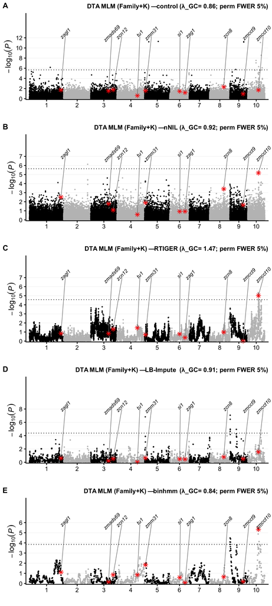

```r
panels <- lapply(names(callers), function(nm) {
  sc <- fread(here(sprintf("data/zeal/dta_gwas_mlm_%s_donor_accession_snp50k.csv", callers[[nm]])))
  plot_manhattan(sc, sprintf("DTA MLM (Family+K) — %s (λ_GC = %.2f; perm FWER 5%%)", nm, lam(sc$P)), overlap_csv = overlap, lod = gwas_thr(TR, "mlm", callers[[nm]]))
})
cc <- cowplot::plot_grid(plotlist = panels, ncol = 1, labels = LETTERS[1:5], label_size = 18, align = "v", axis = "lr")
ggsave(here("results/sim/zeal/dta_caller_composite_fdr_snp50k.png"), cc, width = 9, height = 20, dpi = 200, bg = "white")
cc
```